# BALANCE OF PAYMENT ANALYSIS

```r
library(dplyr)
library(ggplot2)
library(ezids)
library(tidyr)
library(RColorBrewer)
library(patchwork)
```

# 1 INTRODUCTION

The Balance of Payments Statistics (BOPS) database is like a big collection of information that helps us understand how different countries do business with each other. It tells us things like how much money a country earns from selling things to other countries and how much it spends on buying things from other countries. It also shows us how countries invest in each other. This information is important because it helps governments and businesses make decisions about trade and investments. The BOPS database has data from many countries, and it explains how they collect and organize this information.

## 1.1 PROBLEM STATEMENTS

This research project aims to conduct a comprehensive global analysis of key economic indicators, such as Capital Accounts, Net Lending/Borrowing, and Balance on Goods, Services, and Income. Utilizing a dataset that encompasses all the countries and spans from 2015 to 2020, the study will explore trends, correlations, and impacts of these indicators on economic development. focusing on changes over time, correlations between different accounts, and global economic stability. The findings of this research could offer valuable insights for policymakers, economists, and researchers interested in global economic trends and their implications.

### 1.1.1 FINANCIAL ACCOUNT ANALYSIS

Within the context of financial account analysis, I aim to identify patterns in financial accounts and their shifts between being lenders and borrowers from 2015 to 2020.

### 1.1.2 ANALYSIS OF RESERVE ASSETS, PORTFOLIO INVESTMENTS, AND FINANCIAL STABILITY

In the dynamic world of global finance, understanding the reserve assets, portfolio investments, and financial stability of countries is paramount. These metrics are essential barometers of a nation’s economic health, investment strategies, and preparedness against financial adversities. In this section, we will dissect these components using key indicators to shed light on the underlying patterns, strategies, and financial robustness of countries from 2015 to 2020. This analysis is crucial to understand the financial health, resilience, and strategies adopted by nations over the years 2015-2020.

### 1.1.3 TRADE BALANCE ANALYSIS

The balance of payments is a critical component of a country’s economic health, revealing the intricate web of financial transactions between the country and the rest of the world. One essential aspect of this analysis is calculating trade balances. Trade balances are a reflection of the disparity between the value of a country’s exports and imports, providing insights into its economic performance.

In this section, we focus on specific data related to trade balances, exploring the use of trade indicators , “Current Account, Goods and Services, Credit” and “Current Account, Goods and Services, Debit”, Capital Account, Total, Net, US Dollars. Our goals: determine trade balances for countries and analyze changes in net capital accounts. Additionally, we examine shifts in net capital accounts from 2015 to 2020. This paper outlines our methodology, findings, and visual representations, providing insights into international financial transactions and economic dynamics.

Trade balance: The trade balance is a measure of a country’s economic transactions with the rest of the world, reflecting the difference between the value of a nation’s exports (goods and services sold to other countries) and its imports (goods and services purchased from other countries) over a specific period.

### 1.1.4 CURRENT ACCOUNT ANALYSIS

What is the current account balance and what components contribute to it (e.g., trade balance, income, transfers)?

## 1.2 DATA

The Balance of Payments (BOP) dataset at hand is a comprehensive record encompassing over around 5000 rows of economic transactions between various countries and the global community. This dataset is an invaluable source of information, showcasing the intricacies of international financial relations over the years. The dataset is segmented into key components, including the Current Account, Capital Account, and Financial Account. These components track trade in goods and services, income generated from foreign investments, and exchanges of financial assets, elucidating each nation’s economic interactions with the rest of the world. With detailed records on lending, borrowing, trade, and investments, this dataset provides a treasure trove of insights into global financial dynamics. It allows for in-depth analyses, illustrating the trends, anomalies, and case studies that shape international economics, and serves as a foundation for understanding the financial health and transactions of different countries.

## 1.3 DATA CHARACTERISTICS

Our data set consists following fields:

1. **X**: A unique index or row number, assigned to each row in the dataset.
2. **Country**: A factor variable with 171 levels, representing different countries involved in the financial transactions. Each row corresponds to a specific country’s data.
3. **Code**: Another factor variable with 171 levels, which represent a country or transaction code. This field is associated with the countries or entities participating in the transactions.
4. **Indicator**: This is a factor variable with 31 levels, describing the nature or category of the financial indicator. It specifies the type of financial transaction, such as Capital Account, Capital Transfers, Credit, etc.
5. **Icode**: Similar to the “Indicator,” this factor variable with 31 levels It provides additional code information associated with the financial indicators. It could be another categorization or identification system.
6. **X2015**, **X2016**, **X2017**, **X2018**, **X2019**, **X2020**: These are numerical columns, containing financial data for each country’s transactions for the years 2015 to 2020. The numbers likely represent monetary values, possibly in US Dollars, for different financial indicators and transactions.

## 1.4 DATA CLEANING

The data cleaning process was pivotal in shaping the dataset for analysis. Initially, it contained approximately 200,000 rows and included data related to around 110 different economic indicators. To streamline the dataset and focus on the most relevant indicators for our specific problem statement, we retained the frequently occurring and economically significant indicators. In doing so, we ensured that our data would be both manageable and directly applicable to our analytical goals. As a result, the dataset was pruned down to around 5,000 rows.As a result,We have involved two key steps to enhance data quality. First, all rows containing missing or incomplete values in the economic indicators were removed to maintain the dataset’s accuracy and completeness. Secondly, countries with fewer than 20 available economic indicators were excluded. This decision was made to focus the analysis on regions with substantial economic data, ensuring the resulting dataset is both structured and reliable. By eliminating inconsistencies and ensuring data integrity, we created a refined dataset suitable for robust analyses of economic indicators and their implications for the financial performance and stability of different countries.

```r
unique_indi <- unique(df_filtered$Indicator)
print(unique_indi)
```

```
##  [1] "Capital Account, Total, Net, US Dollars"
##  [2] "Net Lending (+) / Net Borrowing (-) (Balance from Current and Capital Account), US Dollars"
##  [3] "Capital Account, Total, Credit, US Dollars"
##  [4] "Capital Account, Total, Debit, US Dollars"
##  [5] "Current Account, Goods and Services, Credit, US Dollars"
##  [6] "Current Account, Goods and Services, Debit, US Dollars"
##  [7] "Financial Account, Portfolio Investment, Net Acquisition of Financial Assets, Equity and Investment Fund Shares, US Dollars"
##  [8] "Capital Account, Capital Transfers, Net, US Dollars"
##  [9] "Financial Account, Portfolio Investment, Net Acquisition of Financial Assets, Debt Securities, US Dollars"
## [10] "Financial Account, Other Investment, Loans, Net Incurrence of Liabilities, Other Sectors, US Dollars"
## [11] "Financial Account, Other Investment, Loans, Net Incurrence of Liabilities, US Dollars"
## [12] "Financial Account, Other Investment, Loans, US Dollars"
## [13] "Current Account, Primary Income, Investment Income, Direct Investment, Debit, US Dollars"
## [14] "Financial Account, Other Investment, Loans, Net Acquisition of Financial Assets, US Dollars"
## [15] "Financial Account, Other Investment, Loans, Net Incurrence of Liabilities, General Government, Other Long-term, US Dollars"
```

[output cut: 16 more lines]

**After removing unwanted data and conducting the necessary data cleaning steps, we successfully isolated a collection of 31 key economic indicators for each country. These indicators have been thoughtfully curated for their relevance to our specific research objectives. They will form the foundational elements for our in-depth problem statement analysis.**

# 2 EXPLOTARY DATA ANALYSIS

## 2.1 FINANCIAL ACCOUNT ANALYSIS

**The indicators for financial account analysis.**

1)Financial Account, Net Lending (+) / Net Borrowing (-) (Balance from Financial Account), Direct Investment, Net Acquisition of Financial Assets, Equity and Investment Fund Shares, Equity Other Than Reinvestment of Earnings, US Dollars

2)Financial Account, Net Lending (+) / Net Borrowing (-) (Balance from Financial Account), Direct Investment, Net Acquisition of Financial Assets, Equity and Investment Fund Shares, US Dollars

3)Financial Account, Net Lending (+) / Net Borrowing (-) (Balance from Financial Account), Direct Investment, Net Acquisition of Financial Assets, US Dollars

4)Financial Account, Net Lending (+) / Net Borrowing (-) (Balance from Financial Account), Direct Investment, Net Incurrence of Liabilities, Debt Instruments, US Dollars

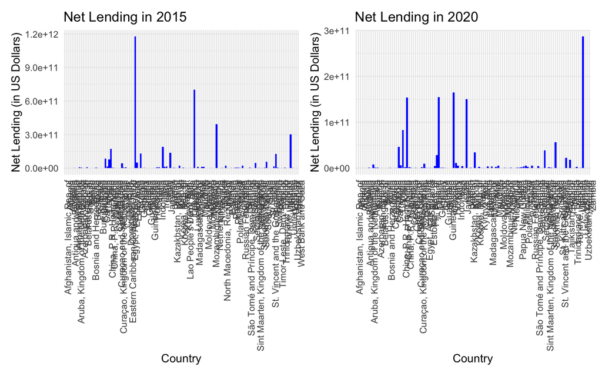

```r
combined_plot <- plotL2015 + plotL2020
print(combined_plot)
```

[figure not shown]

```r
combined_plot <- plotL2015 + plotL2020
print(combined_plot)
```

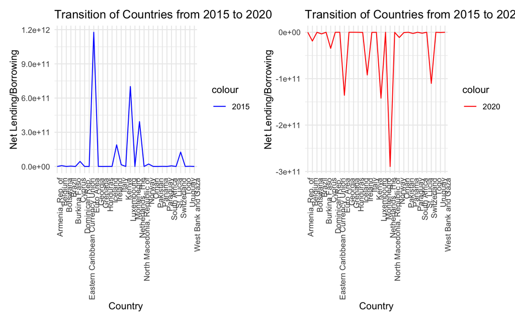

```r
combined_plot <- plot2015 + plot2020
print(combined_plot)
```

**1.Transition of Countries from Lenders to Borrowers in 2015:**

In this graph, countries that were lenders in 2015 are depicted in blue lines. The lines turn red when they transition to being borrowers in 2020. This visualization allows you to easily identify countries that underwent a significant shift in their financial role from lenders to borrowers between these two years.

**2.Transition of Countries from Lenders to Borrowers in 2020:**

In this graph, countries that were lenders in 2015 are initially depicted in blue lines. Those that transitioned to borrowers in 2020 are represented by red lines. This graph is complementary to the first one and helps you see if there have been any new transitions from lender to borrower status in 2020.

**Prediction:-** The transition of a country from being a lender to a borrower may indicate changes in its economic stability or financial health. By analyzing these transitions, you can make predictions about economic conditions and stability in specific regions. For example, countries transitioning from lenders to borrowers might be experiencing economic challenges or shifts in their financial policies. These transitions can be indicative of broader global economic trends. You can make predictions about the overall global economic landscape. For instance, a noticeable increase in the number of countries transitioning to borrowers could suggest a global economic downturn or increased borrowing trends. Next, we will analyze the potential causes of these transitions by examining the various account balances of countries.

## 2.2 ANALYSIS OF RESERVE ASSETS, PORTFOLIO INVESTMENTS, AND FINANCIAL STABILITY

**Indicators Explained:**

1. **Total Current + Capital Account (in USD):**

   Implication: Reflects a country’s total transactions with the rest of the world. It combines the net income from foreign sources and capital transfers, providing insights into a nation’s financial interactions globally.
2. **Reserve Assets (with Fund Record, in USD):**

   Implication: Indicates the foreign currency reserves and gold held by a country’s central bank. A critical metric, it signifies a country’s capability to stabilize its currency and manage external economic shocks.
3. **Reserve Position in the Fund (with Fund Record, in USD):**

   Implication: Reflects a country’s quota in the IMF and its financial commitment to it. It’s an indicator of a nation’s position and influence in global monetary matters.
4. **Portfolio Investment, Net Acquisition of Financial Assets (in USD):**

   Implication: Captures a country’s net gains from financial investments. It offers a glimpse into the nation’s investment success and financial asset management strategies.
5. **Portfolio Investment, Net Acquisition of Financial Assets, Equity and Investment Fund Shares (in USD):**

   Implication: Focuses on the equity aspect of financial investments, revealing preferences towards stocks and shares and indicating the risk appetite of a nation.
6. **Portfolio Investment, Net Acquisition of Financial Assets, Debt Securities (in USD):**

   Implication: Focuses on the debt aspect of financial investments. It’s a measure of a country’s inclination towards bonds and other debt instruments, revealing its creditworthiness and financial stability.

**Objectives:**

1. To explore the distribution and trends in reserve assets and portfolio investments.
2. To determine the impact of these factors on a country’s financial stability.
3. To test specific hypotheses related to the average values of key financial metrics.

**Methodology:** We will embark on a journey of exploratory data analysis, employing visualizations and descriptive statistics. Additionally, hypothesis tests, including t-tests and correlation analysis, will be utilized to draw concrete conclusions.

#### 2.2.0.1 How have the global trends evolved for the “Total Current + Capital Account” from 2015 to 2020 ?

This question aims to understand how countries’ financial summaries (both earnings and big investments/sales) have changed over time. It can reveal global economic patterns, periods of growth or recession, and general financial health trends among countries. If the `Total Current + Capital Account` is increasing over time, it suggests countries are improving their financial positions, either through trade, investments, or other financial activities. Conversely, a declining trend might indicate economic challenges.

By plotting time series data for many countries on a single graph, the visualization became cluttered, making it difficult to discern patterns. Hence, a more effective strategy would be to segregate the countries into two categories: `Top 10 countries by economy` and `Top 10 emerging countries.`

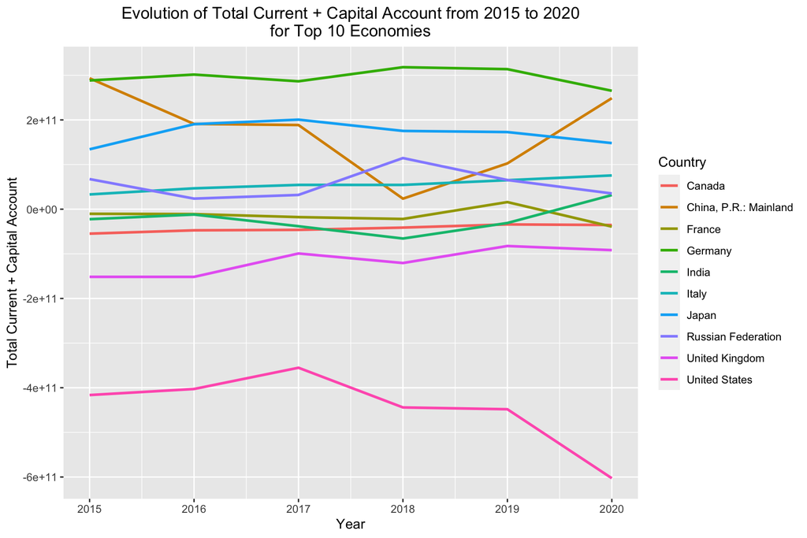

```r
# top 10 countires by economy
top_10_Economic_Countries <- c("United States", "China, P.R.: Mainland", "Japan", "Germany", "India", "United Kingdom",
                               "France", "Russian Federation", "Canada", "Italy")

# top 10 emerging countries
top_10_emerging_countries <- c("Brazil", "Russian Federation", "India", "China, P.R.: Mainland", "South Africa",
                               "Mexico", "Indonesia", "Türkiye, Rep. of", "Nigeria", "Philippines")

# Load the necessary libraries


# Filter data for the top 10 economies
top_10_economies_data <- subset(long_data, Country %in% top_10_Economic_Countries)

# Plot for top 10 economies
plot_top_10_economies <- ggplot(top_10_economies_data, aes(x=Year, y=Value, group=Country, color=Country)) +
  geom_line(linewidth=1) +
  labs(title="Evolution of Total Current + Capital Account from 2015 to 2020\nfor Top 10 Economies",
       y="Total Current + Capital Account",
       x="Year") +
  theme(legend.position="right",
        plot.title=element_text(hjust=0.5))

# Display the plots
plot_top_10_economies
```

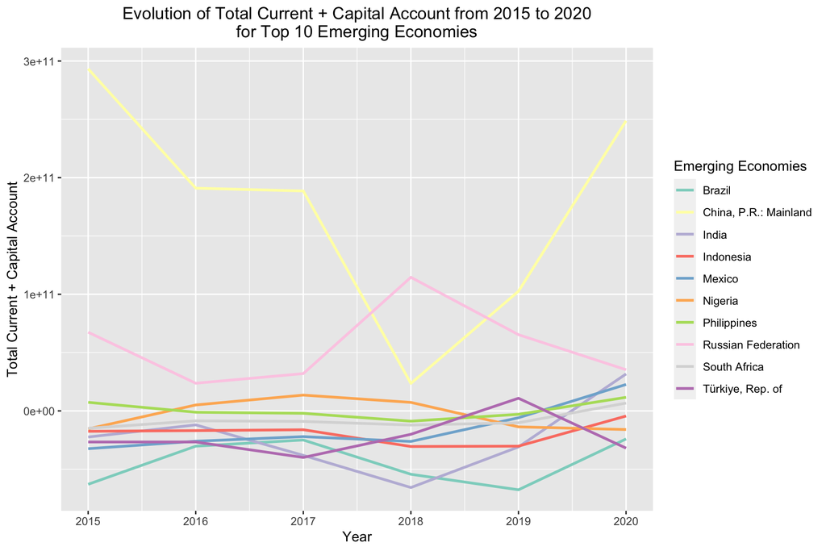

```r
# Filter data for the top 10 emerging economies
top_10_emerging_data <- subset(long_data, Country %in% top_10_emerging_countries)

# Plot for top 10 emerging economies
plot_top_10_emerging <- ggplot(top_10_emerging_data, aes(x=Year, y=Value, group=Country, color=Country)) +
  geom_line(linewidth=1) +
  labs(title="Evolution of Total Current + Capital Account from 2015 to 2020\nfor Top 10 Emerging Economies",
       y="Total Current + Capital Account",
       x="Year") +
  scale_color_brewer(palette="Set3", name="Emerging Economies") +
    theme(legend.position="right",
        plot.title=element_text(hjust=0.5))

# Display the plots
plot_top_10_emerging
```

#### 2.2.0.2 How does the distribution of ‘Net Acquisition of Financial Assets’ look like for countries in 2020? Are there outliers ?

**Real-world implications:**

1. **Understanding Economic Health:** The distribution of `Net Acquisition of Financial Assets` can provide insights into how countries are managing their finances, specifically in terms of acquiring assets in `2020`.
2. **Economic Strategies and Policies:** By identifying outliers, we can pinpoint countries that deviate significantly from the average. This could be due to unique economic strategies, policies, or circumstances faced by those nations.
3. **Financial Stability and Risk:** Countries with extremely high or low net acquisitions might be seen as more volatile or risky from an investment perspective. On the other hand, countries close to the median or mean might be perceived as more stable.

(Log transformation was applied to handle vast data ranges and reduce outlier influence, ensuring clearer visualizations and robust analysis for both, the histogram, and the box plot.)

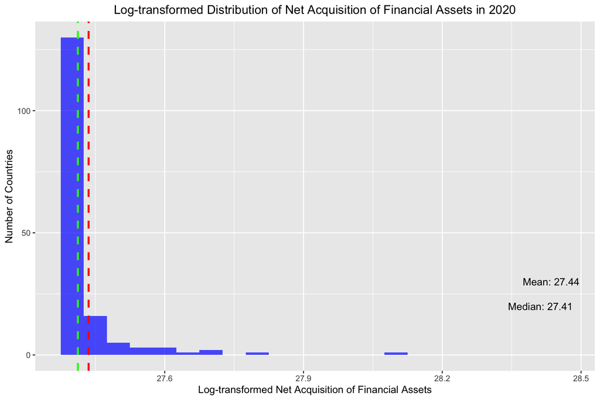

```r
# Extract the data for the 'Net Acquisition of Financial Assets' in 2020
data_2020 <- relevant_financial_metrics$X2020[relevant_financial_metrics$Indicator == "Financial Account, Portfolio Investment, Net Acquisition of Financial Assets, US Dollars"]

# Calculate statistics for the original data
mean_value <- mean(data_2020, na.rm = TRUE)
median_value <- median(data_2020, na.rm = TRUE)
max_value <- max(data_2020, na.rm = TRUE)

# Calculate statistics for the original data
Q1 <- quantile(data_2020, 0.25, na.rm = TRUE)
Q3 <- quantile(data_2020, 0.75, na.rm = TRUE)
IQR_value <- IQR(data_2020, na.rm = TRUE)
lower_whisker <- Q1 - 1.5 * IQR_value
upper_whisker <- Q3 + 1.5 * IQR_value
range_value <- range(data_2020, na.rm = TRUE)
outliers <- data_2020[data_2020 < lower_whisker | data_2020 > upper_whisker]

# Apply a log transformation to the data; adding a small constant to handle zeros or negative values
log_data_2020 <- log(data_2020 + max(abs(data_2020))*1.01)

# Calculate statistics for the transformed data
mean_log_value <- mean(log_data_2020, na.rm = TRUE)
median_log_value <- median(log_data_2020, na.rm = TRUE)

# Plotting the histogram
ggplot(data.frame(Value=log_data_2020), aes(x=Value)) +
  geom_histogram(binwidth=0.05, fill="blue", alpha=0.7) +
  geom_vline(aes(xintercept=mean_log_value), color="red", linetype="dashed", size=1) +
  geom_vline(aes(xintercept=median_log_value), color="green", linetype="dashed", size=1) +
  annotate("text", x = mean_log_value + 1, y = 30, label = paste("Mean:", round(mean_log_value, 2))) +
  annotate("text", x = median_log_value + 1, y = 20, label = paste("Median:", round(median_log_value, 2))) +
  labs(title="Log-transformed Distribution of Net Acquisition of Financial Assets in 2020",
       x="Log-transformed Net Acquisition of Financial Assets",
       y="Number of Countries") +
  theme(legend.position="right",
        plot.title=element_text(hjust=0.5))
```

**Summary of Net Acquisition of Financial Assets in 2020:**

1. **Median Acquisition:** Most countries have a net acquisition of financial assets less than `75.5 million` USD in `2020`.
2. **Highest Acquisition:** The highest net acquisition of financial assets among all countries in `2020` was `795 billion` USD.
3. **Average Acquisition:** On average, countries had a net acquisition of financial assets of about `21.74 billion` USD in `2020`
4. **Distribution Shape:** The majority of countries display a concentrated, low net acquisition, suggesting a global trend or cautious financial behavior in `2020`.
5. **Presence of Outliers:** The considerable gap between the highest acquisition (795 billion USD) and the median (75.5 million USD) indicates that there are countries with exceptionally high financial asset acquisitions, diverging from the norm. These could be global financial hubs or countries with unique financial activities in `2020`.
6. **Right-Skewed Distribution:** Most countries have modest net acquisitions, but a few report significantly higher values, indicating varied financial strategies or conditions.

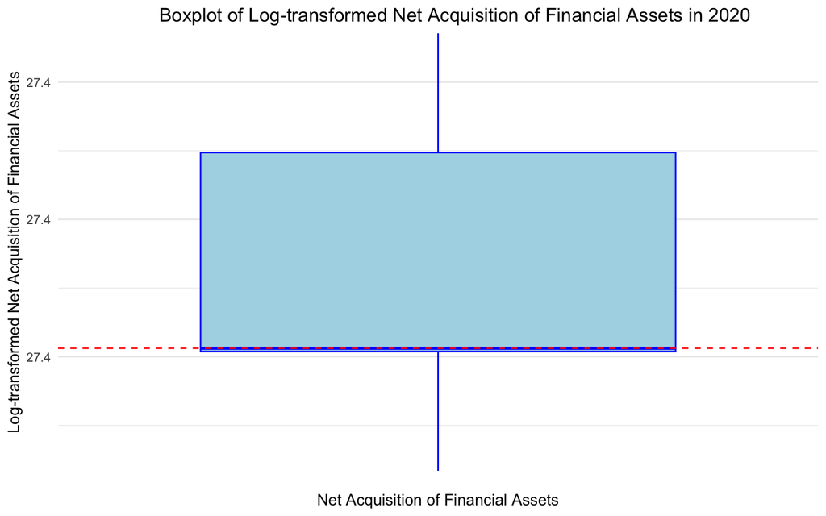

```r
# Determine the 1st and 3rd quartiles and IQR
Q1 <- quantile(log_data_2020, 0.25)
Q3 <- quantile(log_data_2020, 0.75)
IQR_value <- IQR(log_data_2020)

# Using ggplot2 to create a boxplot with customized y-axis limits
ggplot(data.frame(Value=log_data_2020), aes(x="", y=Value)) +
  geom_boxplot(fill="lightblue", color="blue", outlier.shape=NA) +
  geom_hline(yintercept = median(log_data_2020), linetype="dashed", color = "red", size=0.5) +  # Median line
  labs(title="Boxplot of Log-transformed Net Acquisition of Financial Assets in 2020",
       x = "Net Acquisition of Financial Assets",
       y="Log-transformed Net Acquisition of Financial Assets") +
  theme_minimal() +
    theme(plot.title=element_text(hjust=0.6)) +
  coord_cartesian(ylim=c(Q1 - 0.5*IQR_value, Q3 + 0.5*IQR_value))
```

**Insights from the Net Acquisition of Financial Assets in 2020:**

1. **Central Acquisition Trend:** Half of the countries had a net acquisition of financial assets less than `75.5 million` USD in `2020`, indicating a modest median value midst a large spread.
2. **Variability in Acquisitions:** The middle `50%` of countries’ net acquisitions ranged from virtually nothing (or even slight losses) up to `4.67 billion` USD, highlighting a vast disparity in financial asset acquisitions.
3. **Overall Acquisition Extremes:** The overall range of net acquisitions spanned from a net loss of `6.42 billionr` USD to a remarkable gain of `795.47 billion` USD.
4. **Identifying Anomalies:** There were `31` countries whose net acquisitions were notably higher or lower than the general trend, warranting further investigation into their unique financial contexts.
5. **Typical Acquisition Ranges:** The whiskers extend from `-7 billion` to `11.67 billion`, encompassing the typical range of acquisitions, while outliers lie beyond this span.

These conclusions underscore the varied financial positions and strategies of countries in `2020`, with some nations demonstrating significant prowess or challenges in their net acquisitions of financial assets.

#### 2.2.0.3 Do countries with higher average ‘Equity and Investment Fund Shares’ over the period 2015-2020 also possess higher average ‘Debt Securities’ during the same period?

In the financial world, both `Equity and Investment Fund Shares` and `Debt Securities` are ways to raise capital. The former refers to ownership in a company or investment fund, while the latter represents borrowing, typically through issuing bonds.

If countries with higher average equity and investment fund shares also tend to have higher debt securities, it could indicate several things:

1. **Balanced Financial Instruments:** The country is leveraging both ownership (equity) and borrowing (debt) as means to finance its operations, projects, or investments.
2. **Economic Growth and Infrastructure Development:** The country might be in a phase of rapid growth or infrastructure development, which requires significant capital. This capital is sourced both from equity investments and borrowings.

```r
# filter the data for the two indicators
equity_data <- relevant_financial_metrics[relevant_financial_metrics$Indicator == "Financial Account, Portfolio Investment, Net Acquisition of Financial Assets, Equity and Investment Fund Shares, US Dollars", ]
debt_data <- relevant_financial_metrics[relevant_financial_metrics$Indicator == "Financial Account, Portfolio Investment, Net Acquisition of Financial Assets, Debt Securities, US Dollars", ]

# Calculate the mean for the years 2015-2020 for each country
equity_data$mean_equity <- rowMeans(equity_data[,c("X2015", "X2016", "X2017", "X2018", "X2019", "X2020")], na.rm = TRUE)
debt_data$mean_debt <- rowMeans(debt_data[,c("X2015", "X2016", "X2017", "X2018", "X2019", "X2020")], na.rm = TRUE)

# Merge the datasets by country
merged_data <- merge(equity_data[,c("Country", "mean_equity")], debt_data[,c("Country", "mean_debt")], by="Country")

# Calculate the correlation
correlation <- cor(merged_data$mean_equity, merged_data$mean_debt, use="complete.obs")
```

**Correlation Analysis of Average ‘Equity and Investment Fund Shares’ and ‘Debt Securities’ (2015-2020):**

The Pearson’s correlation coefficient is `0.775` which is quite substantial, suggesting a strong positive linear relationship between the two variables.

This positive correlation suggests several potential real-world scenarios:

1. **Investment Attraction:** Countries that attract more equity investments might be perceived as economically stable or promising, leading to more investments in their debt securities as well.
2. **Economic Policies:** Some countries might have policies that promote both `equity` and `debt` investments, leading to growth in both areas.

However, it’s essential to remember that **correlation does not imply causation**. While the two variables move together, it doesn’t necessarily mean that an increase in one causes an increase in the other.

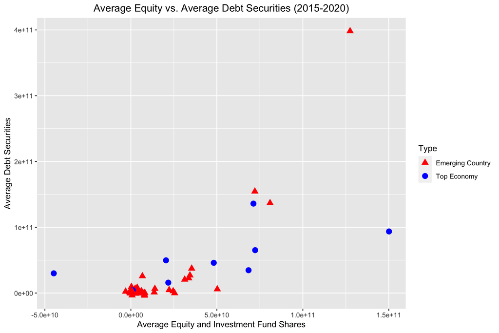

```r
# filter the data for the two indicators
equity_data <- relevant_financial_metrics[relevant_financial_metrics$Indicator == "Financial Account, Portfolio Investment, Net Acquisition of Financial Assets, Equity and Investment Fund Shares, US Dollars", ]
debt_data <- relevant_financial_metrics[relevant_financial_metrics$Indicator == "Financial Account, Portfolio Investment, Net Acquisition of Financial Assets, Debt Securities, US Dollars", ]

# Calculate the mean for the years 2015-2020 for each country
equity_data$mean_equity <- rowMeans(equity_data[,c("X2015", "X2016", "X2017", "X2018", "X2019", "X2020")], na.rm = TRUE)
debt_data$mean_debt <- rowMeans(debt_data[,c("X2015", "X2016", "X2017", "X2018", "X2019", "X2020")], na.rm = TRUE)

# Merge the datasets by country
merged_data <- merge(equity_data[,c("Country", "mean_equity")], debt_data[,c("Country", "mean_debt")], by="Country")

# Create a new column to identify whether the country is a top economy or emerging
merged_data$Type <- ifelse(merged_data$Country %in% top_10_Economic_Countries, "Top Economy", "Emerging Country")

# Scatter plot differentiating between the top 10 economies and the top 10 emerging countries
ggplot(merged_data, aes(x=mean_equity, y=mean_debt, color=Type)) +
  geom_point(aes(shape=Type), size=3) +
  labs(title="Average Equity vs. Average Debt Securities (2015-2020)",
       x="Average Equity and Investment Fund Shares",
       y="Average Debt Securities") +
  theme(legend.position="right", plot.title=element_text(hjust=0.5)) +
  scale_color_manual(values=c("Top Economy"="blue", "Emerging Country"="red")) +
  scale_shape_manual(values=c("Top Economy"=19, "Emerging Country"=17))
```

**Differentiation between Top Economies and Emerging Countries:**

From a real-world perspective, this scatter plot provides insights into the financial health and strategies of countries. `Top economies`, with their mature financial markets, are actively involved in both `equity investments` and acquiring `debt securities`. Emerging countries, while showing potential and growth, exhibit more variability, which could be due to multiple factors like economic policies, geopolitical issues, or developmental stages.

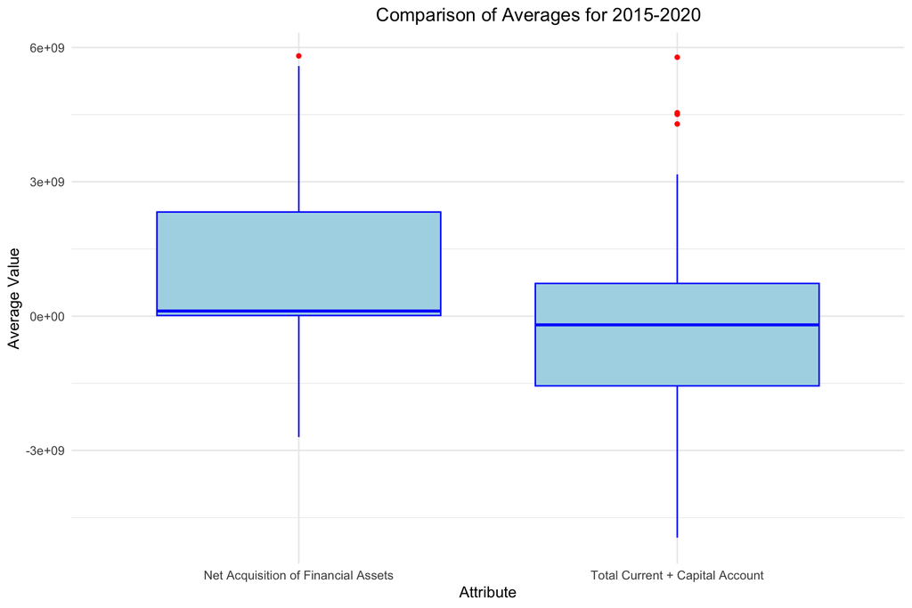

```r
# Extracting data
supplementary_accnts_data <- relevant_financial_metrics[relevant_financial_metrics$Indicator == "Supplementary Items, Total Current + Capital Account, US Dollars", ]
financial_accnts_data <- relevant_financial_metrics[relevant_financial_metrics$Indicator == "Financial Account, Portfolio Investment, Net Acquisition of Financial Assets, US Dollars", ]

# Calculating averages for 2015-2020
supplementary_accnts_data$average <- rowMeans(supplementary_accnts_data[, c("X2015", "X2016", "X2017", "X2018", "X2019", "X2020")], na.rm = TRUE)
financial_accnts_data$average <- rowMeans(financial_accnts_data[, c("X2015", "X2016", "X2017", "X2018", "X2019", "X2020")], na.rm = TRUE)

# Combine the data for boxplot
boxplot_data <- data.frame(
  Value = c(supplementary_accnts_data$average, financial_accnts_data$average),
  Type = c(rep("Total Current + Capital Account", nrow(supplementary_accnts_data)),
           rep("Net Acquisition of Financial Assets", nrow(financial_accnts_data)))
)

# Determine the 1st and 3rd quartiles and IQR for the y-axis limits
Q1_supplementary <- quantile(supplementary_accnts_data$average, 0.25, na.rm = TRUE)
Q3_supplementary <- quantile(supplementary_accnts_data$average, 0.75, na.rm = TRUE)
IQR_supplementary <- IQR(supplementary_accnts_data$average, na.rm = TRUE)

Q1_financial <- quantile(financial_accnts_data$average, 0.25, na.rm = TRUE)
Q3_financial <- quantile(financial_accnts_data$average, 0.75, na.rm = TRUE)
IQR_financial <- IQR(financial_accnts_data$average, na.rm = TRUE)

# Using ggplot2 to create a boxplot with customized y-axis limits
ggplot(boxplot_data, aes(x=Type, y=Value)) +
  geom_boxplot(fill="lightblue", color="blue", outlier.color="red", outlier.shape=16) +
  labs(title="Comparison of Averages for 2015-2020",
       y="Average Value",
       x="Attribute") +
  theme_minimal() +
  theme(plot.title=element_text(hjust=0.6)) +
  coord_cartesian(ylim=c(min(Q1_supplementary - 1.5*IQR_supplementary, Q1_financial - 1.5*IQR_financial),
                         max(Q3_supplementary + 1.5*IQR_supplementary, Q3_financial + 1.5*IQR_financial)))
```

## 2.3 TRADE BALANCE ANALYSIS

**Indicators Explained:**

1. Current Account, Goods and Services, Credit, US Dollars- This indicator represents the financial transactions associated with a country’s international trade in goods and services. “Credit” in this context means income generated from exports of goods and services to other countries.
2. Current Account, Goods and Services, Debit, US Dollars- This indicator represents the financial transactions related to a country’s imports of goods and services from other nations.

“Debit” in this context signifies the expenditures made on imports.

3. Capital Account, Total, Net, US Dollars- The capital account, in the context of the balance of payments, deals with the financial flows associated with capital transactions between a country and the rest of the world. “Net” in this indicator refers to the difference between capital inflows and capital outflows.

```r
trade_balance_data <- BOP %>%
  filter(Indicator == "Current Account, Goods and Services, Credit, US Dollars" |
         Indicator == "Current Account, Goods and Services, Debit, US Dollars") %>%
  mutate(Trade_Balance_2015 = `X2015` - `X2020`,
         Trade_Balance_2016 = `X2016` - `X2020`,
         Trade_Balance_2017 = `X2017` - `X2020`,
         Trade_Balance_2018 = `X2018` - `X2020`,
         Trade_Balance_2019 = `X2019` - `X2020`)
```

```r
country_group <- trade_balance_data %>%
 group_by(Country) %>%
  mutate(difference = Trade_Balance_2015 - lag(Trade_Balance_2015, default = Trade_Balance_2015[1]))
```

```r
Country_selecter <- trade_balance_data %>%
  filter(Country == 'Algeria')
```

```r
Algeria_selected <- country_group%>%
  filter(Country == 'Algeria')
```

```r
Algeria_tradebalance <- trade_balance_data%>%
  filter(Country == 'Algeria') %>%
  select(Country, Indicator,Trade_Balance_2015, Trade_Balance_2016, Trade_Balance_2017, Trade_Balance_2018, Trade_Balance_2019)
print(Algeria_tradebalance)
```

```
##   Country                                               Indicator
## 1 Algeria Current Account, Goods and Services, Credit, US Dollars
## 2 Algeria  Current Account, Goods and Services, Debit, US Dollars
##   Trade_Balance_2015 Trade_Balance_2016 Trade_Balance_2017 Trade_Balance_2018
## 1           1.30e+10           7.84e+09           1.28e+10           1.95e+10
## 2           2.09e+10           1.78e+10           1.77e+10           1.77e+10
##   Trade_Balance_2019
## 1           1.36e+10
## 2           1.19e+10
```

**How Did Algeria’s Trade Balances Evolve Over the Period 2015-2019?**

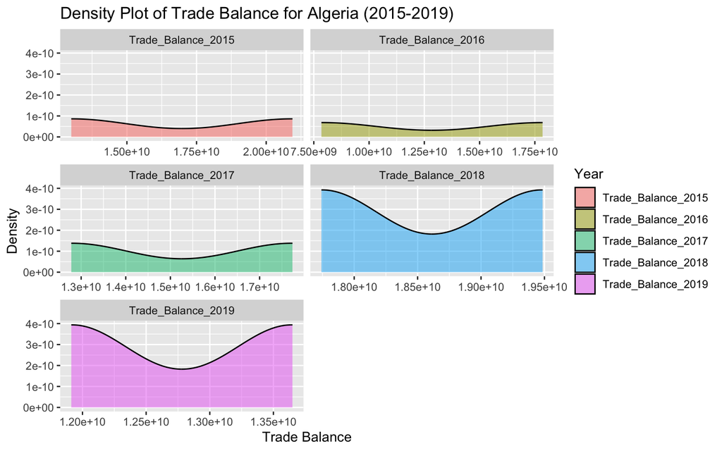

```r
Algeria_tradebalance_filtered <- Algeria_tradebalance %>%
  select(Trade_Balance_2015, Trade_Balance_2016, Trade_Balance_2017, Trade_Balance_2018, Trade_Balance_2019)


Algeria_tradebalance_filtered_long <- tidyr::gather(Algeria_tradebalance_filtered, Year, Trade_Balance, 1:5)


ggplot(Algeria_tradebalance_filtered_long, aes(x = Trade_Balance, fill = Year)) +
  geom_density(alpha = 0.5) +
  labs(x = "Trade Balance", y = "Density") +
  ggtitle("Density Plot of Trade Balance for Algeria (2015-2019)")+
  facet_wrap(~Year, scales = "free_x", ncol = 2)
```

**Findings:** Our analysis revealed intriguing insights into trade balances. By segregating data based on countries, we explored the nuances of trade balances for specific nations. For instance, our investigation focused on Algeria. We noted the disparities between credit and debit transactions over the years, gaining a comprehensive understanding of trade balance dynamics.

**Changes in Net Capital Accounts:** In our subsequent analysis, we delved into changes in net capital accounts. Initially, we filtered the Balance of Payments (BOP) dataset to include only these specific indicators- “Capital Account, Total, Net, US Dollars.” Then, we selected the relevant columns, which included country names and data for the years 2015-2020, providing a comprehensive overview of net capital accounts for all countries.

We then focused on a specific case: **Australia** We examined how Australia’s net capital accounts changed from 2015 to 2020, offering insights into their evolution over time. This detailed examination enriched our understanding of net capital accounts and provided valuable insights into economic trends.

```r
Net_countries <- BOP %>%
  filter(Indicator == 'Capital Account, Total, Net, US Dollars') %>%
  select(Country, 'X2015','X2016','X2017','X2018','X2019','X2020')
```

```r
data_longer <- Net_countries %>%
  filter(Country == 'Australia') %>%
  gather(Country, Value)
print(data_longer )
```

```
##   Country     Value
## 1   X2015 -4.56e+08
## 2   X2016 -6.07e+08
## 3   X2017 -3.88e+08
## 4   X2018 -3.55e+08
## 5   X2019 -5.54e+08
## 6   X2020 -7.27e+08
```

Furthermore, we employed line graphs to depict changes in net capital accounts,focusing on Australia for the years 2015 to 2020. These line graphs provided a clear and structured representation of how net capital accounts evolved over the selected time frame, offering insights into Australia’s financial dynamics.

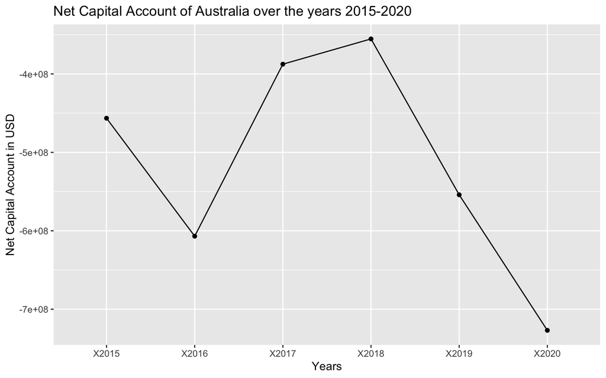

```r
line_graph <- ggplot(data_longer, aes(x = Country, y = Value, group = 1)) +
  geom_line() +
  geom_point() +
  labs(x = "Years", y = "Net Capital Account in USD") +
  ggtitle("Net Capital Account of Australia over the years 2015-2020")
print(line_graph)
```

1. In our analysis of the net capital account of Australia from 2015 to 2020, we observed significant fluctuations. The initial years, particularly 2017 and 2018, showed notable increases, suggesting heightened capital movements. However, a pivotal moment occurred in 2019, with a substantial decrease in the net capital account, marking a turning point in the data. The lowest point was reached in 2020, indicating a need for closer scrutiny.
2. This graph emphasized the importance of monitoring net capital accounts over time to assess a country’s financial stability and identify potential economic trends and challenges. The fluctuations we observed in this period prompted further analysis to understand the underlying factors driving these changes and their implications for Australia’s economic landscape.

**Findings:** Our research extended to net capital accounts, with a specific focus on Australia. We tracked changes in net capital accounts from 2015 to 2020. The findings unveiled fluctuations in the country’s net capital account over this period, demonstrating the influence of various economic factors.

## 2.4 CURRENT ACCOUNT BALANCE

```r
head(df_filtered)
```

```
##   X                      Country Code
## 1 1 Afghanistan, Islamic Rep. of  512
## 2 2 Afghanistan, Islamic Rep. of  512
## 3 3 Afghanistan, Islamic Rep. of  512
## 4 4 Afghanistan, Islamic Rep. of  512
## 5 5 Afghanistan, Islamic Rep. of  512
## 6 6 Afghanistan, Islamic Rep. of  512
##                                                                                    Indicator
## 1                                                    Capital Account, Total, Net, US Dollars
## 2 Net Lending (+) / Net Borrowing (-) (Balance from Current and Capital Account), US Dollars
## 3                                                 Capital Account, Total, Credit, US Dollars
## 4                                                  Capital Account, Total, Debit, US Dollars
## 5                                    Current Account, Goods and Services, Credit, US Dollars
## 6                                     Current Account, Goods and Services, Debit, US Dollars
##           Icode     X2015     X2016     X2017     X2018     X2019     X2020
## 1    BK_BP6_USD  1.32e+09  1.29e+09  1.31e+09  1.31e+09  1.19e+09  7.53e+08
## 2  BACK_BP6_USD -2.87e+09 -1.42e+09 -2.25e+09 -2.58e+09 -2.60e+09 -2.38e+09
## 3 BK_CD_BP6_USD  1.32e+09  1.29e+09  1.31e+09  1.31e+09  1.19e+09  7.53e+08
## 4 BK_DB_BP6_USD  0.00e+00  0.00e+00  0.00e+00  0.00e+00  0.00e+00  0.00e+00
## 5  BXGS_BP6_USD  1.42e+09  1.14e+09  1.15e+09  1.61e+09  1.52e+09  1.48e+09
## 6  BMGS_BP6_USD  8.46e+09  7.33e+09  7.96e+09  7.99e+09  7.37e+09  6.98e+09
```

```r
summary(df_filtered)
```

```
##        X          Country               Code      Indicator
##  Min.   :   1   Length:4959        Min.   :111   Length:4959
##  1st Qu.:1688   Class :character   1st Qu.:288   Class :character
##  Median :3180   Mode  :character   Median :542   Mode  :character
##  Mean   :3202                      Mean   :540
##  3rd Qu.:4786                      3rd Qu.:746
##  Max.   :6327                      Max.   :968
##     Icode               X2015               X2016               X2017
##  Length:4959        Min.   :-4.16e+11   Min.   :-4.44e+11   Min.   :-3.55e+11
##  Class :character   1st Qu.: 0.00e+00   1st Qu.: 0.00e+00   1st Qu.: 0.00e+00
##  Mode  :character   Median : 6.26e+07   Median : 6.55e+07   Median : 8.31e+07
##                     Mean   : 1.43e+10   Mean   : 1.33e+10   Mean   : 1.57e+10
##                     3rd Qu.: 1.21e+09   3rd Qu.: 1.19e+09   3rd Qu.: 1.49e+09
##                     Max.   : 3.24e+12   Max.   : 3.24e+12   Max.   : 3.57e+12
##      X2018               X2019               X2020
##  Min.   :-6.20e+11   Min.   :-4.48e+11   Min.   :-6.03e+11
##  1st Qu.: 0.00e+00   1st Qu.: 0.00e+00   1st Qu.: 0.00e+00
##  Median : 6.90e+07   Median : 9.66e+07   Median : 9.74e+07
##  Mean   : 1.41e+10   Mean   : 1.56e+10   Mean   : 1.45e+10
##  3rd Qu.: 1.28e+09   3rd Qu.: 1.60e+09   3rd Qu.: 1.55e+09
##  Max.   : 3.87e+12   Max.   : 3.81e+12   Max.   : 3.50e+12
```

```r
currentaccount_df <- df_filtered[grepl("^Current Account", df_filtered$Indicator), ]
```

**THE SIX ECONOMICS INDICATORS AND ITS SIGNIFICANCES** 1)Current Account, Goods and Services, Credit, US Dollars 2)Current Account, Goods and Services, Debit, US Dollars 3)Current Account, Primary Income, Investment Income, Direct Investment, Credit, US Dollars 4)Current Account, Primary Income, Investment Income, Direct Investment, Debit, US Dollars 5)Current Account, Goods and Services, Services, Transport, Credit, US Dollars 6)Current Account, Goods and Services, Services, Transport, Debit, US Dollars

**Trade Balance (Credit and Debit):** The first and second indicators, “Current Account, Goods and Services, Credit, US Dollars” and “Current Account, Goods and Services, Debit, US Dollars,” signify a country’s trade balance. The “Credit” side represents the value of goods and services a nation exports, while the “Debit” side indicates what it imports. The difference between the two reveals whether a country has a trade surplus (more exports than imports) or a trade deficit (more imports than exports).

**Primary Income Balance (Credit and Debit):** The third and fourth indicators, “Current Account, Primary Income, Investment Income, Direct Investment, Credit, US Dollars” and “Current Account, Primary Income, Investment Income, Direct Investment, Debit, US Dollars,” detail a country’s primary income balance. “Credit” shows income earned from foreign direct investments, while “Debit” represents payments made to foreign investors. This balance reflects how much a country gains or loses through international investments.

**Transport Balance (Credit and Debit):** The fifth and sixth indicators, “Current Account, Goods and Services, Services, Transport, Credit, US Dollars” and “Current Account, Goods and Services, Services, Transport, Debit, US Dollars,” signify the transport balance. “Credit” tracks income from transport services offered to other countries, while “Debit” denotes payments made for inbound transport services. This balance showcases the economic flow related to transportation.

**Current Account Balance:**

By summing the Trade Balance, Primary Income Balance, and Transport Balance, we arrive at the Current Account Balance. This comprehensive metric provides a holistic view of a nation’s economic interactions with the world. A positive balance indicates that a country is earning more from international trade, investments, and transport services than it’s spending, signifying economic strength. Conversely, a negative balance suggests deficits and potential financial challenges.

These indicators collectively allow economists and policymakers to assess a country’s international trade performance, financial stability, and its ability to attract investments and generate income from various economic activities. They are instrumental in understanding a nation’s economic health and its position in the global marketplace.

```r
currentaccount_df$Total <- rowSums(currentaccount_df[, grep("X20(15|16|17|18|19|20)", colnames(currentaccount_df))], na.rm = TRUE)

# Filter rows where Indicator contains "credit"
credit_data <- currentaccount_df[currentaccount_df$Indicator == "Current Account, Goods and Services, Credit, US Dollars", ]

# Filter rows where Indicator contains "Debit"
debit_data <- currentaccount_df[currentaccount_df$Indicator == "Current Account, Goods and Services, Debit, US Dollars", ]

credit_grouped <- aggregate(Total ~ Country, data = credit_data, sum)
debit_grouped <- aggregate(Total ~ Country, data = debit_data, sum)

trade_balance_data_total <- merge(credit_grouped, debit_grouped, by = "Country", all = TRUE)
trade_balance_data_total$Trade_Balance <- trade_balance_data_total$Total.x - trade_balance_data_total$Total.y
trade_balance_data_total$Trade_Balance_mean <- trade_balance_data_total$Trade_Balance /6

# Filter rows where Indicator contains "credit"
credit_data_income <- currentaccount_df[currentaccount_df$Indicator == "Current Account, Primary Income, Investment Income, Direct Investment, Credit, US Dollars", ]

# Filter rows where Indicator contains "Debit"
debit_data_income <- currentaccount_df[currentaccount_df$Indicator == "Current Account, Primary Income, Investment Income, Direct Investment, Debit, US Dollars", ]

credit_grouped_income <- aggregate(Total ~ Country, data = credit_data_income, sum)
debit_grouped_income <- aggregate(Total ~ Country, data = debit_data_income, sum)

income_balance_data_Total <- merge(credit_grouped_income, debit_grouped_income, by = "Country", all = TRUE)
income_balance_data_Total$income_Balance <- income_balance_data_Total$Total.x - income_balance_data_Total$Total.y
income_balance_data_Total$income_Balance_mean <- income_balance_data_Total$income_Balance /6

# Filter rows where Indicator contains "credit"
credit_data_transport <- currentaccount_df[currentaccount_df$Indicator == "Current Account, Goods and Services, Services, Transport, Credit, US Dollars", ]

# Filter rows where Indicator contains "Debit"
debit_data_transport <- currentaccount_df[currentaccount_df$Indicator == "Current Account, Goods and Services, Services, Transport, Debit, US Dollars", ]

credit_grouped_transport <- aggregate(Total ~ Country, data = credit_data_transport, sum)
debit_grouped_transport <- aggregate(Total ~ Country, data = debit_data_transport, sum)

transport_balance_data_Total <- merge(credit_grouped_transport, debit_grouped_transport, by = "Country", all = TRUE)
transport_balance_data_Total$transport_Balance <- transport_balance_data_Total$Total.x - transport_balance_data_Total$Total.y
transport_balance_data_Total$transport_Balance_mean<-transport_balance_data_Total$transport_Balance/6
merged_df <- merge(trade_balance_data_total, income_balance_data_Total, by = "Country")
merged_df <- merge(merged_df, transport_balance_data_Total, by = "Country")
result_df <- merged_df[, c("Country", "Trade_Balance", "Trade_Balance_mean", "income_Balance", "income_Balance_mean", "transport_Balance", "transport_Balance_mean")]
result_df$Current_Account_Balance <- result_df$Trade_Balance + result_df$income_Balance + result_df$transport_Balance
result_df$Current_Account_Balance <- result_df$Trade_Balance + result_df$income_Balance + result_df$transport_Balance
```

### 2.4.1 CURRENT ACCOUNT BALANCE FOR VARIOUS COUNTRIES

[figure not shown]

```r
ggplot(result_df, aes(x = Current_Account_Balance)) +
  geom_histogram(fill = "lightblue", color = "black") +
  labs(title = "Distribution of Current Account Balances Across 171 Countries", x = "Current Account Balance (in Billions of US Dollars)" , y = "Number of Countries")
```

From the graph it is evident that more than 120 countries have their current account balances in the central tendency region

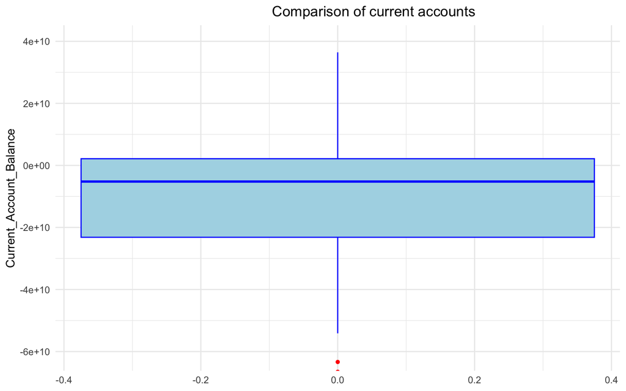

```r
Q1_Currentaccount <- quantile(result_df$Current_Account_Balance, 0.25, na.rm = TRUE)
Q3_Currentaccount <- quantile(result_df$Current_Account_Balance, 0.75, na.rm = TRUE)
IQR_currentaccount <- IQR(result_df$Current_Account_Balance, na.rm = TRUE)


ggplot(result_df, aes(y=Current_Account_Balance)) +
  geom_boxplot(fill="lightblue", color="blue", outlier.color="red", outlier.shape=16) +
  labs(title="Comparison of current accounts",
       y="Current_Account_Balance") +
  theme_minimal() +
  theme(plot.title=element_text(hjust=0.6)) +
  coord_cartesian(ylim=c(min(Q1_Currentaccount - 1.5*IQR_currentaccount),
                         max(Q3_Currentaccount + 1.5*IQR_currentaccount)))
```

*Distribution of Current Account Balances Across Countries*

# 3 HYPOTHESIS TESTING

```r
data_borrowers <- transition_to_borrowers
data_lenders <- transition_to_lenders
data_borrowers$Group <- "Borrower"
data_lenders$Group <- "Lender"
combined_data_2020 <- rbind(data_borrowers, data_lenders)
model_2020 <- aov(X2020 ~ Group, data = combined_data_2020)
summary(model_2020)
```

```
##             Df   Sum Sq  Mean Sq F value Pr(>F)
## Group        1 1.55e+22 1.55e+22    4.74  0.035 *
## Residuals   45 1.47e+23 3.26e+21
## ---
## Signif. codes:  0 '***' 0.001 '**' 0.01 '*' 0.05 '.' 0.1 ' ' 1
```

**Null hypothesis (H0)**: states that there is no significant difference between the groups. In this case, it means that the means of financial indicator X2020 are equal for both Borrowers and Lenders.

**Alternative hypothesis (Ha)**: asserts that there is indeed a significant difference between the groups.

After conducting this hypothesis test, the resulting p-value suggests that there is a significant difference between the groups, meaning that the transitions of countries are associated with specific financial indicators.

This test is crucial for subsequent financial account analysis, as it provides statistical evidence that the group of financial indicators plays a role in the transitions of countries. It provides the foundation for our data analysis.

The average ‘Total Current + Capital Account’ is equal to the average ‘Net Acquisition of Financial Assets’ for countries in 2020.

This hypothesis aims to determine if the combined total of the current and capital accounts for countries (which includes trade balances and primary incomes) is equivalent to the net increase in a country’s holdings of foreign financial assets. In simple terms, it’s comparing the overall balance of payments with how much new foreign financial assets a country is acquiring.

If the hypothesis is true, it might suggest that, on average, countries are maintaining a balance between their trade and income flows and their acquisition of foreign financial assets. If it’s not true, then countries might be leaning more towards either maintaining their trade balances or acquiring foreign assets, which could have implications for their overall financial health and strategy.

**Null Hypothesis (Ho):** The average `Total Current + Capital Account` is equal to the average `Net Acquisition of Financial Assets` for countries in 2020.

**Alternative Hypothesis (Ha):** The average `Total Current + Capital Account` is not equal to the average `Net Acquisition of Financial Assets` for countries in 2020.

# 4 CONCLUSION

**Throughout our detailed analysis of current accounts, capital accounts, financial accounts, and supplementary accounts from 2015 to 2020, several key insights emerged:**

**Independent Financial Dynamics:** The various elements from current accounts, capital accounts, financial accounts, and supplementary accounts operate largely independently. A country’s position in one facet doesn’t necessarily dictate its standing in another, highlighting the intricate and multifaceted nature of financial ecosystems.

**Diverse Growth Patterns:** An evident observation is that growth trajectories are not universally mirrored across countries. Each nation’s economic story is unique, driven by its individual circumstances, choices, and challenges.

**Beyond Financial Indicators:** While these indicators provide a valuable glimpse into the financial pulse of countries, it’s crucial to recognize their limitations. Factors such as exceptional financial events, policy shifts, cultural nuances, geographic considerations, and political landscapes play significant roles in shaping a country’s economic trajectory. These multifaceted influences underline the importance of a holistic approach when evaluating a nation’s financial health and future prospects.

Financial indicators provide a structured glimpse into a country’s economic standing, yet the real-world picture is far more intricate. Beyond these numbers lie various determinants that shape a nation’s financial narrative. Our analysis, while comprehensive, is just an initial step in decoding the multifaceted realm of global finance.

## 4.1 FUTURE SCOPE

**1) Predictive Modeling:** Given the historical data on financial indicators, predictive models can be developed to forecast future values, aiding in proactive financial planning for countries.

**2) Multivariate Analysis:** By understanding the relationships and interactions between various financial indicators, multivariate models can offer insights into combined effects and potential synergies.

**3) Clustering and Classification:** Based on financial patterns observed, countries can be grouped into clusters or classified into categories, offering insights into nations with similar financial behaviors or risks.

## 4.2 REFRENCES

1.) Shlaymoon, N. S., Jassim, A. M., & Albairmani, A. M. A. (2022). Relationship between Exchange Rate and the Current Account of the Balance of Payments: A Study in Oil Countries Selected. Webology, 19(1), 5170-5180.

2.) Dluhosch, B., Freytag, A., & Krüger, M. (1996). International competitiveness and the balance of payments: Do current account deficits and surpluses matter? E. Elgar Pub.

3.) Shlaymoon, N. S., Jassim, A. M., & Albairmani, A. M. A. (2022). Relationship between exchange rate and the current account of the balance of payments: A study in oil countries selected. Webology, 19(1), 5170-5180.

4.) Sharma, J., Rai, A., Rathee, N., & Mehendale, M. S. (2018). Study on factors that affect the Indian balance of payments: A methodological overview and thematic review. Asian Journal of Management, 9(1), 847.

5.) Alencar, D. A., & Strachman, E. (2014). Balance-of-payments-constrained growth in Brazil: 1951-2008. Journal of Post Keynesian Economics, 36(4), 673-698.